```r
library(pheatmap)
library(edgeR)
library(DESeq2)
library(biomaRt)
library(ggplot2)
library(topGO)
require(plyr)
library(GOplot)
library("org.Hs.eg.db")
```

Read in files with read counts.

```r
filename2 = "~/Downloads/readcounts_iHEP.txt"
counts = read.table(filename2, header = T, stringsAsFactors = F)
```

Remove metadata (Gene, coordinates, etc)

```r
counts_matrix = data.matrix(counts[,grep ("bam", colnames(counts))])
colnames(counts_matrix) = matrix(unlist(strsplit(colnames(counts_matrix), "algn.")), byrow =T, ncol=3)[,2]
rownames(counts_matrix) = counts$Geneid

#rename columns/sample to reflect useful labels
key = read.table("~/Downloads/metadata_Duwaerts_iHEP.txt", header = T, stringsAsFactors = F, fill=T, sep="\t")
head(key)
```

```
##               FILE.NAME BOX.FOLDER.LOCATION SAMPLE.TYPE SAMPLE.NAME
## 1  1_S1_R1_001.fastq.gz                iHEP        iHEP           1
## 2  2_S2_R1_001.fastq.gz                iHEP        iHEP           2
## 3  7_S3_R1_001.fastq.gz                iHEP        iHEP           7
## 4 12_S4_R1_001.fastq.gz                iHEP        iHEP          12
## 5 15_S5_R1_001.fastq.gz                iHEP        iHEP          15
## 6 20_S6_R1_001.fastq.gz                iHEP        iHEP          20
##     DISEASE.STATUS                                      NOTES
## 1          CONTROL
## 2          CONTROL
## 3             NASH
## 4             NASH
## 5 NASH (STEATOSIS)
## 6             NASH Considered an outlier in original analysis
```

```r
renamesample=list()
for (x in 1:nrow(key)){
  key$FILE.NAME[x] = sub("-", ".", key$FILE.NAME[x])  #issues with "-" in fastq file names
  oldname = paste0(sub(".fastq.gz", "", key$FILE.NAME[x], "_"), "_")
  newname = paste(key$SAMPLE.TYPE[x], key$SAMPLE.NAME[x], key$DISEASE.STATUS[x], sep="_")
  renamesample[oldname] = newname
}

colnames(counts_matrix) = unlist(lapply (colnames(counts_matrix), function(x) renamesample[[x]]))
colnames(counts_matrix) = sub ("NASH \\(STEATOSIS\\)", "NASH", colnames(counts_matrix))
```

Filter out genes that are too highly expressed or lowly expressed. Highly expressed genes are usually mitochondrial.

```r
keep = rowMeans(counts_matrix) > 5 & rowMeans(counts_matrix) < 5000
counts_matrix_filtered = counts_matrix[keep,]
```

Take the RPKM.

```r
y <- DGEList(counts=counts_matrix_filtered)
fpkm_matrix = rpkm (y, gene.length=counts[keep,"Length"], log = FALSE)
```

Dendrogram showing relationships using fpkm.

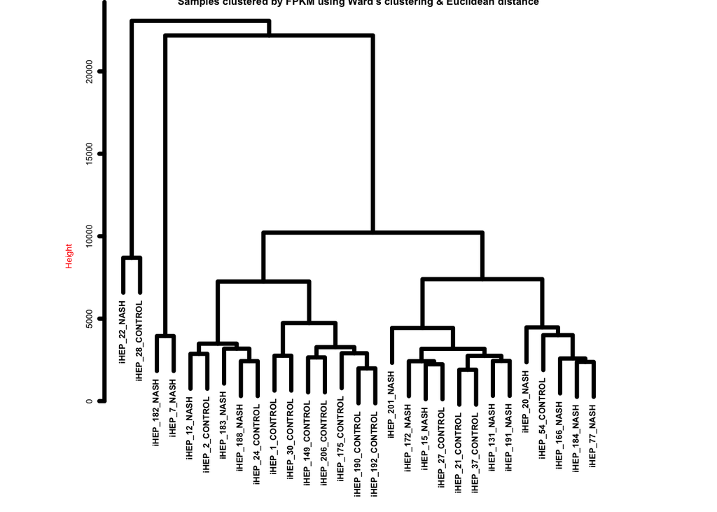

```r
par(cex=.5,font=2)
hc2 <- hclust(stats::dist(t(fpkm_matrix), method="minkowski"), "ward.D2")
par(mar=c(.2,.2,.2,.2), pty='s')
plot(hc2, lwd=4, lty=1, col="black", col.lab="red", xlab="Samples", main="Samples clustered by FPKM using Ward's clustering & Euclidean distance")
```

label each sample by two conditions 1) disease status 2) patient source

```r
DiseaseStatus = factor(matrix (unlist(strsplit(colnames(counts_matrix_filtered), "_")), byrow=T, ncol=3)[,3], levels = c("CONTROL","NASH"))
SampleID = factor(matrix (unlist(strsplit(colnames(counts_matrix_filtered), "_")), byrow=T, ncol=3)[,2])
```

log transformation for PCA plot

```r
cold <- data.frame("DiseaseStatus"=DiseaseStatus)
rownames(cold) = colnames(counts_matrix_filtered)
cold
```

```
##                  DiseaseStatus
## iHEP_12_NASH              NASH
## iHEP_131_NASH             NASH
## iHEP_149_CONTROL       CONTROL
## iHEP_15_NASH              NASH
## iHEP_166_NASH             NASH
## iHEP_172_NASH             NASH
## iHEP_175_CONTROL       CONTROL
## iHEP_182_NASH             NASH
## iHEP_183_NASH             NASH
## iHEP_184_NASH             NASH
## iHEP_188_NASH             NASH
## iHEP_190_CONTROL       CONTROL
## iHEP_191_NASH             NASH
## iHEP_192_CONTROL       CONTROL
## iHEP_1_CONTROL         CONTROL
## iHEP_201_NASH             NASH
## iHEP_206_CONTROL       CONTROL
## iHEP_20_NASH              NASH
## iHEP_21_CONTROL        CONTROL
## iHEP_22_NASH              NASH
## iHEP_24_CONTROL        CONTROL
## iHEP_27_CONTROL        CONTROL
## iHEP_28_CONTROL        CONTROL
## iHEP_2_CONTROL         CONTROL
## iHEP_30_CONTROL        CONTROL
## iHEP_37_CONTROL        CONTROL
## iHEP_54_CONTROL        CONTROL
## iHEP_77_NASH              NASH
## iHEP_7_NASH               NASH
```

```r
ddsMat <- DESeq2::DESeqDataSetFromMatrix(countData=counts_matrix_filtered, colData=cold, design=~DiseaseStatus );
colnames(ddsMat) <- colnames(counts_matrix_filtered)
rld <- DESeq2::rlog(ddsMat) # LOG TRANSFORMED.
```

run PCA to explore structure in the data in lower dimensions.

```r
par(mfrow=c(2,1))
pca <- prcomp(t(assay(rld)))
```

Plot PC1 against PC2 using variance stabilizing transformation.

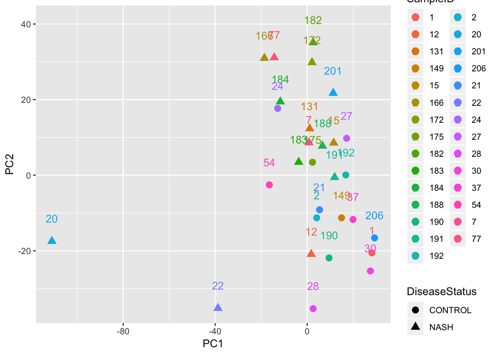

```r
d <- data.frame(pca$x, group=DiseaseStatus, SampleID,  name=colnames(rld)) # returns PC1, PC2, ... PC8... etc
ppp <- ggplot(d, aes_string(x="PC1", y="PC2",shape="DiseaseStatus", color="SampleID"))
ppp <- ppp + geom_point(size=3) + geom_text(aes(label=SampleID), nudge_y=6)
plot(ppp)
```

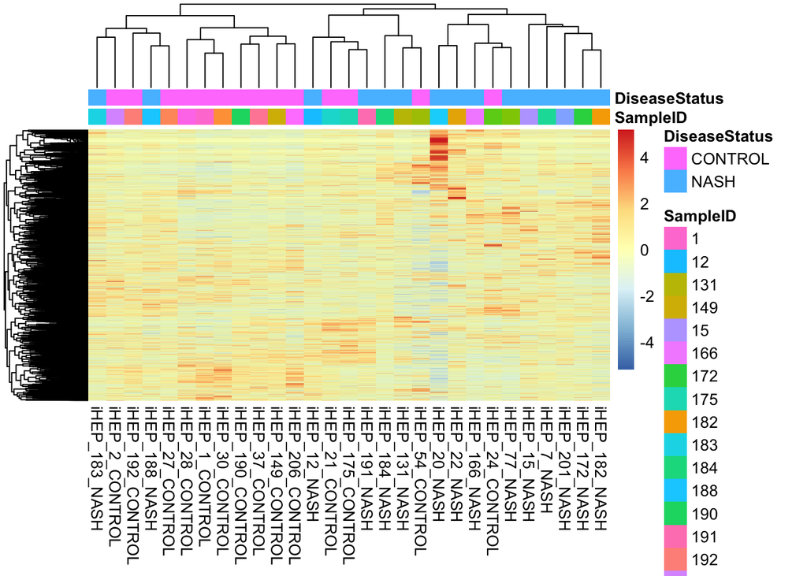

```r
HEATMAP_HEIGHT <- 45 # inchescol
HEATMAP_WIDTH  <- 15
annotation <- data.frame(
  SampleID= SampleID, DiseaseStatus=DiseaseStatus)
rownames(annotation) <- colnames(fpkm_matrix)
pheatmap(fpkm_matrix,
         , width=HEATMAP_WIDTH, height=HEATMAP_HEIGHT
         , scale="row"  # actually scale each row
         , clustering_distance_rows="correlation" # or: euclidean
         , clustering_distance_cols="correlation"
         , clustering_method="complete"
         , display_numbers=FALSE
         , border_color="#00000000" # note: the last two digits here are the alpha channel/ transparency
         , show_rownames=FALSE, show_colnames = TRUE
         , annotation = annotation
         , fontsize_row=3.5)
```

```r
design_matrix <- model.matrix( ~ DiseaseStatus  )
colnames(design_matrix)
```

```
## [1] "(Intercept)"       "DiseaseStatusNASH"
```

```r
design_matrix
```

```
##    (Intercept) DiseaseStatusNASH
## 1            1                 1
## 2            1                 1
## 3            1                 0
## 4            1                 1
## 5            1                 1
## 6            1                 1
## 7            1                 0
## 8            1                 1
## 9            1                 1
## 10           1                 1
## 11           1                 1
## 12           1                 0
## 13           1                 1
## 14           1                 0
```

[output cut: 20 more lines]

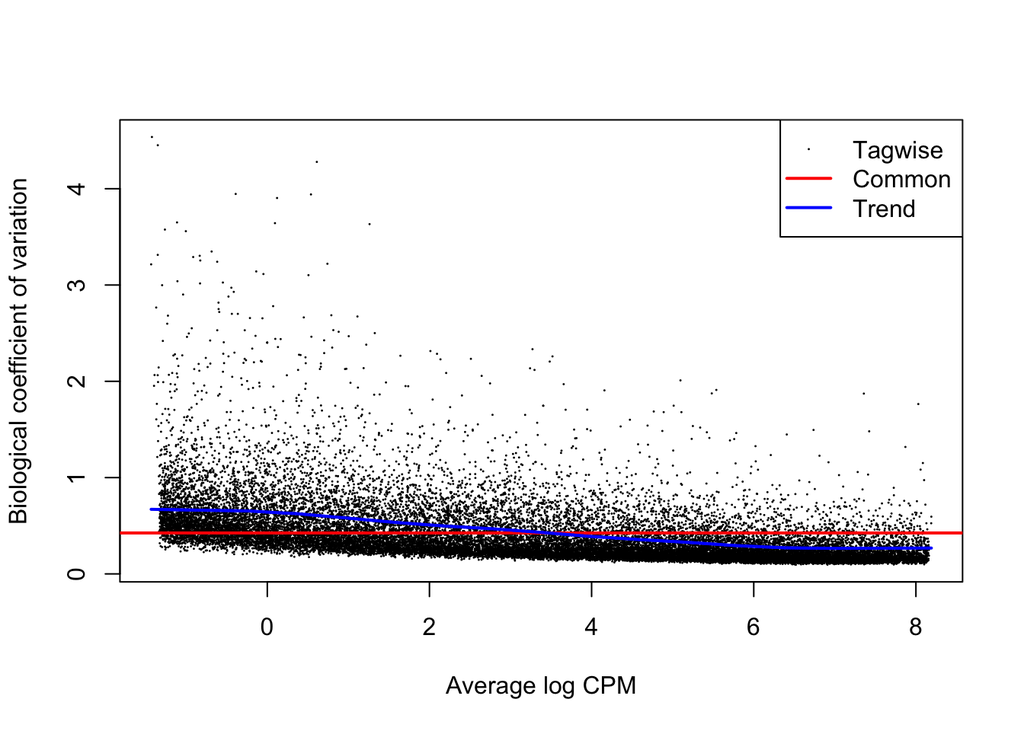

```r
y_for_DE <- DGEList(counts=counts_matrix_filtered)
y_for_DE <- calcNormFactors(y_for_DE)
y_for_DE = estimateDisp(y_for_DE, design=design_matrix)
plotBCV(y_for_DE)
```

```r
fit <- glmFit(y_for_DE, design=design_matrix, dispersion=y_for_DE$trended.dispersion)
```

Somewhat high trended estimated dispersion values (expect something around .4).

NASH vs Control

```r
lrt <- glmLRT(fit, coef = "DiseaseStatusNASH")
topTags(lrt)
```

```
## Coefficient:  DiseaseStatusNASH
##                    logFC   logCPM       LR        PValue           FDR
## ENSG00000263963 4.852944 5.784328 644.1606 4.159747e-142 1.073880e-137
## ENSG00000231501 5.018720 5.421333 587.1247 1.057600e-129 1.365151e-125
## ENSG00000145423 7.448101 3.517567 483.9150 3.005038e-107 2.585935e-103
## ENSG00000186340 5.527761 3.945798 415.8290  1.973854e-92  1.273925e-88
## ENSG00000096088 3.059213 6.810593 378.4071  2.765401e-84  1.427832e-80
## ENSG00000169347 2.976271 8.057744 360.4978  2.193804e-80  9.439206e-77
## ENSG00000011465 3.030822 5.538469 277.4410  2.711825e-62  1.000121e-58
## ENSG00000116132 5.977636 2.206181 259.9229  1.783667e-58  5.755895e-55
## ENSG00000182492 3.032959 5.339237 258.2519  4.126300e-58  1.183606e-54
## ENSG00000198868 2.635480 6.021521 255.3487  1.771802e-57  4.574085e-54
```

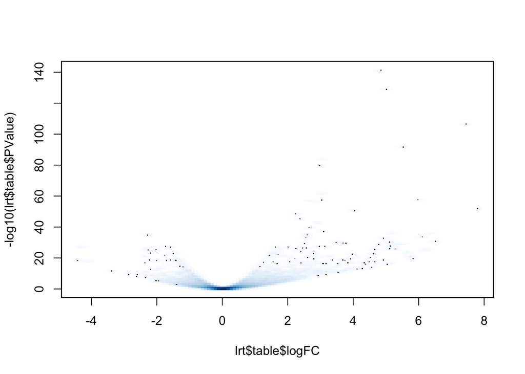

```r
smoothScatter(x=lrt$table$logFC, y=-log10(lrt$table$PValue))
```

Histogram should skew left.

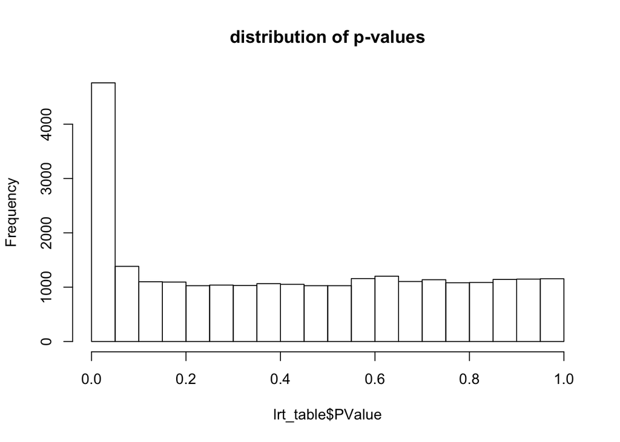

```r
lrt_table = data.frame(lrt$table, p.adjust(lrt$table$PValue, method = "BH"))
colnames(lrt_table) = c(colnames(lrt$table), "adjPVal_BH")
hist(lrt_table$PValue, main="distribution of p-values")
```

Format output into excel sheet.

```r
genes = rownames(counts_matrix_filtered)
ensembl = useEnsembl(biomart="ensembl", dataset="hsapiens_gene_ensembl",host="www.ensembl.org")
head(listAttributes(ensembl), 30)
```

```
##                               name
## 1                  ensembl_gene_id
## 2          ensembl_gene_id_version
## 3            ensembl_transcript_id
## 4    ensembl_transcript_id_version
## 5               ensembl_peptide_id
## 6       ensembl_peptide_id_version
## 7                  ensembl_exon_id
## 8                      description
## 9                  chromosome_name
## 10                  start_position
## 11                    end_position
## 12                          strand
## 13                            band
## 14                transcript_start
```

[output cut: 47 more lines]

```r
hgnc_swissprot <- getBM(attributes=c('ensembl_gene_id','hgnc_symbol','description'),filters = 'ensembl_gene_id',  values = genes , mart = ensembl)

index = match (genes, hgnc_swissprot$ensembl_gene_id)
results = data.frame(hgnc_swissprot[index,], counts_matrix_filtered, fpkm_matrix, lrt_table)
colnames(results) = c(
                    colnames(hgnc_swissprot[index,])
                  , unlist(lapply (colnames(counts_matrix_filtered), function(x) paste(x, "counts", sep="_")))
                  , unlist(lapply (colnames(fpkm_matrix), function(x) paste(x, "fpkm", sep="_")))
                  , unlist(lapply (colnames(lrt_table), function(x) paste(x, "_NASH_vs_CONTROL_baseline", sep="_")))
                  )
curr_date = format(Sys.time(), "%a_%b_%d_%H_hrs_%M_min_%S_sec_%Y")
write.table(results, paste0("~/Downloads/duwaerts_", names(table(key$SAMPLE.TYPE)), "_de_", curr_date, ".xls"), row.names=rownames(counts_matrix_filtered), col.names=NA, sep="\t")
```

Gene Ontology

```r
#setup gene DE for GOplot package later
GOplot_genes = results[grep ("_NASH_vs_CONTROL_baseline",colnames(results))]
colnames(GOplot_genes) = c("logFC", "logCPM", "LR", "Pvalue", "BH")
GOplot_genes["ID"] = results[,"ensembl_gene_id"]
colnames(GOplot_genes)
```

```
## [1] "logFC"  "logCPM" "LR"     "Pvalue" "BH"     "ID"
```

```r
length(unique(GOplot_genes$ID))
```

```
## [1] 25692
```

```r
GOplot_genes = GOplot_genes[, c("ID", "logFC")] #we only need these two columns for TopGO

geneIDs = results[,"ensembl_gene_id"]
inUniverse = geneIDs %in%  results[,"ensembl_gene_id"]
inSelection = geneIDs %in% results[which(results[,"adjPVal_BH__NASH_vs_CONTROL_baseline"] <=0.05),"ensembl_gene_id"]
alg <- factor( as.integer( inSelection[inUniverse] ) )
names(alg) <- geneIDs[inUniverse]
head(alg)
```

```
## ENSG00000223972 ENSG00000227232 ENSG00000278267 ENSG00000243485
##               1               0               0               0
## ENSG00000238009 ENSG00000239945
##               0               0
## Levels: 0 1
```

```r
onts = c( "MF", "BP", "CC" )
tab = as.list(onts)
names(tab) = onts
GOplot_terms=list()
  for(i in 1:3) {
    ## prepare data
    tgd <- new( "topGOdata", ontology=onts[i], allGenes = alg, nodeSize=5,
                 annot=annFUN.org, mapping="org.Hs.eg.db", ID = "ensembl" )

    ## run tests
    resultTopGO.elim <- runTest(tgd, algorithm = "elim", statistic = "Fisher" )
    resultTopGO.classic <- runTest(tgd, algorithm = "classic", statistic = "Fisher" )

    ## look at results
    tab[[i]] <- GenTable( tgd, Fisher.elim = resultTopGO.elim,
        Fisher.classic = resultTopGO.classic,
        orderBy = "Fisher.classic" , topNodes = 200)

    #convert list to dataframe
    allGO = genesInTerm(tgd, tab[[i]][,"GO.ID"])
    test = ldply (lapply(allGO, function(x) paste(x, collapse=",")), data.frame)
    GOplot_terms[[i]] = data.frame(onts[i], tab[[i]], test, stringsAsFactors = FALSE)
    GOplot_terms[[i]][, "Fisher.elim"] = as.numeric(as.character(GOplot_terms[[i]][, "Fisher.elim"]))
    GOplot_terms[[i]][, "Fisher.elim.BH"] = p.adjust(GOplot_terms[[i]][, "Fisher.elim"], method="BH")
    GOplot_terms[[i]] = GOplot_terms[[i]][, c("onts.i.", "GO.ID", "Term", "Fisher.elim.BH", "X..i..")]
    colnames(GOplot_terms[[i]]) = c("Category", "ID", "Term",  "adj_pval", "Genes")
  }
```

[output not shown]

[output not shown]

[output not shown]

[output not shown]

[output not shown]

[output not shown]

[output not shown]

[output not shown]

[output not shown]

[output not shown]

[output not shown]

[output not shown]

[output not shown]

[output not shown]

[output not shown]

[output not shown]

[output not shown]

[output not shown]

[output not shown]

[output not shown]

[output not shown]

[output not shown]

[output not shown]

[output not shown]

[output not shown]

[output not shown]

[output not shown]

[output not shown]

[output not shown]

[output not shown]

[output not shown]

[output not shown]

[output not shown]

[output not shown]

[output not shown]

[output not shown]

[output not shown]

[output not shown]

[output not shown]

[output not shown]

[output not shown]

[output not shown]

[output not shown]

[output not shown]

[output not shown]

[output not shown]

[output not shown]

[output not shown]

[output not shown]

[output not shown]

[output not shown]

[output not shown]

[output not shown]

[output not shown]

[output not shown]

[output not shown]

[output not shown]

[output not shown]

[output not shown]

[output not shown]

[output not shown]

[output not shown]

[output not shown]

[output not shown]

[output not shown]

[output not shown]

[output not shown]

[output not shown]

[output not shown]

[output not shown]

[output not shown]

[output not shown]

[output not shown]

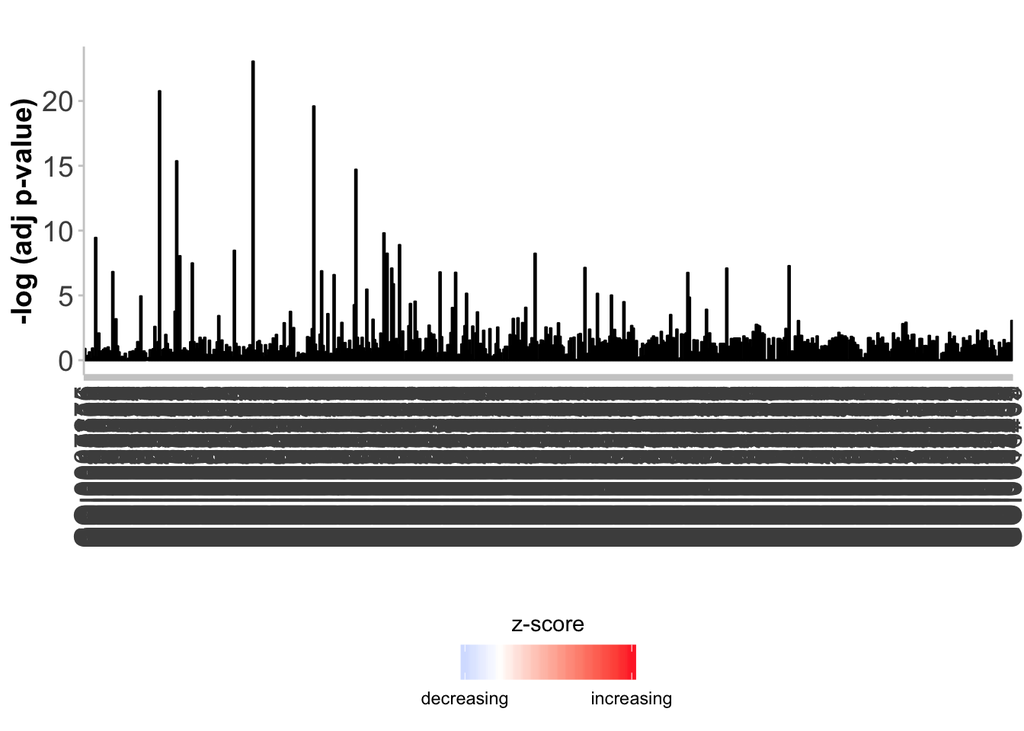

```r
topGOResults <- rbind.fill(tab)
#write.csv(topGOResults, file = "topGOResults.csv")
topGOResults2 <- rbind.fill(GOplot_terms)
write.table(topGOResults2, file = paste0("~/Downloads/duwaerts_", names(table(key$SAMPLE.TYPE)), "_topGO_", curr_date, ".xls"), sep="\t",col.names=NA)


circ <- circle_dat(topGOResults2, data.frame(GOplot_genes))
GOBar(circ)
```

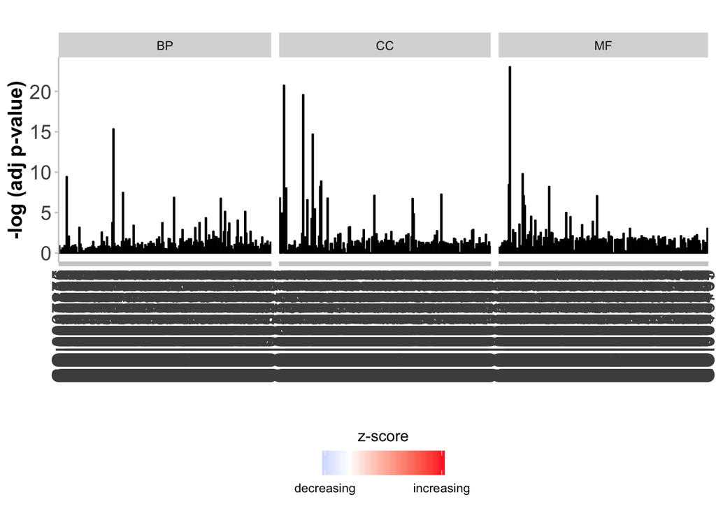

```r
GOBar(circ, display='multiple')
```

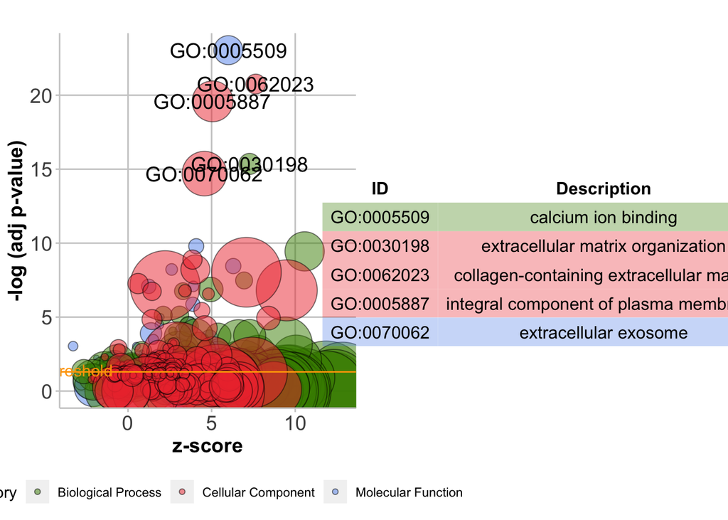

```r
GOBubble(circ, labels = 10)
```

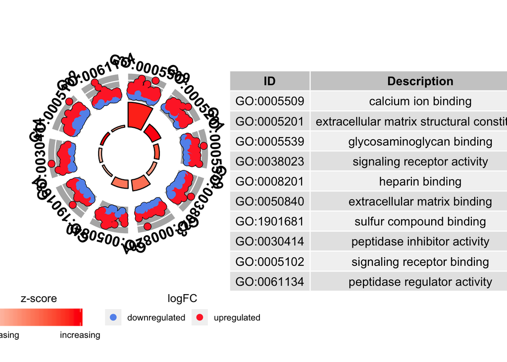

```r
GOCircle(circ)
```

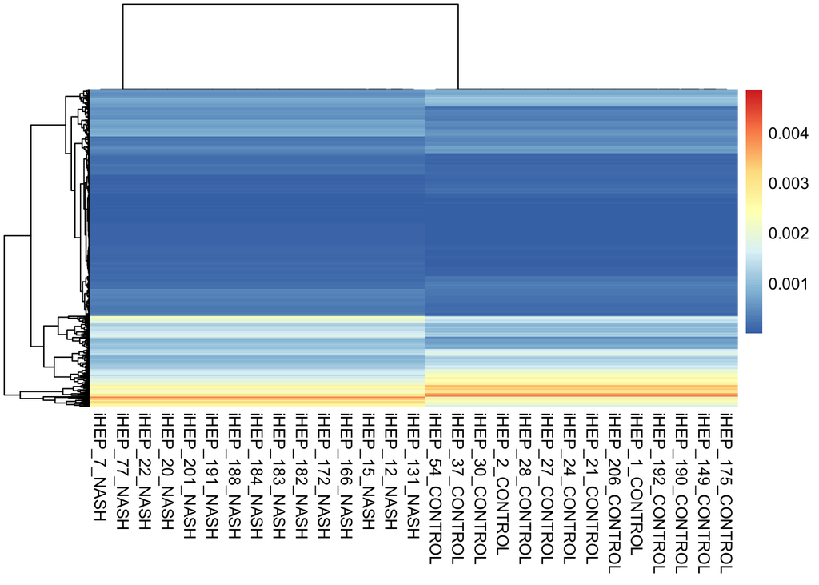

```r
mean_values = 2^((fit$coefficients) %*% t(design_matrix) )
colnames(mean_values) = colnames (counts_matrix_filtered)

de_mean_values = mean_values[rownames(mean_values) %in%  results[which(results[,"adjPVal_BH__NASH_vs_CONTROL_baseline"] <=0.05),"ensembl_gene_id"], ]
pheatmap(de_mean_values,
         , width=HEATMAP_WIDTH, height=HEATMAP_HEIGHT
         #, scale="row"  # actually scale each row
         #, clustering_distance_rows="correlation" # or: euclidean
         , clustering_distance_cols="correlation"
         , clustering_method="complete"
         , display_numbers=FALSE
        , border_color="#00000000" # note: the last two digits here are the alpha channel/ transparency
         , show_rownames=FALSE, show_colnames = TRUE
         #, annotation = annotation
         , fontsize_row=3.5)
```

Differentially expressed genes 2543.

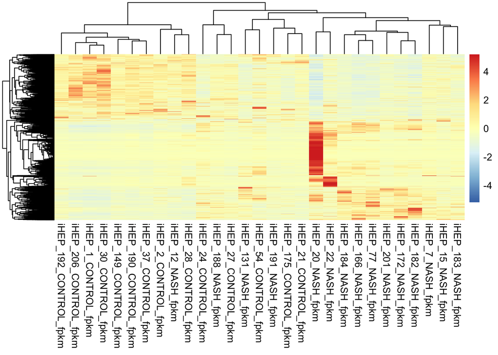

```r
de_fpkm_values = results[which(results[,"adjPVal_BH__NASH_vs_CONTROL_baseline"] <=0.05), grep ("_fpkm", colnames(results))]
pheatmap(de_fpkm_values,
         , width=HEATMAP_WIDTH, height=HEATMAP_HEIGHT
         , scale="row"  # actually scale each row
         #, clustering_distance_rows="correlation" # or: euclidean
         , clustering_distance_cols="correlation"
         , clustering_method="complete"
         , display_numbers=FALSE
        , border_color="#00000000" # note: the last two digits here are the alpha channel/ transparency
         , show_rownames=FALSE, show_colnames = TRUE
         #, annotation = annotation
         , fontsize_row=3.5)
```

TODO: 1) what are the genes that are different in the outlier sample ribosomal? 2) kegg pathway analysis 3) WGCNA

```r
OutlierStatus = factor(colnames(counts_matrix_filtered) %in% c("iHEP_20_NASH", "iHEP_22_NASH", "iHEP_54_CONTROL"), levels = c("FALSE","TRUE"))
design_matrix_outliers <- model.matrix( ~ OutlierStatus  )
colnames(design_matrix_outliers)
```

```
## [1] "(Intercept)"       "OutlierStatusTRUE"
```

```r
design_matrix_outliers
```

```
##    (Intercept) OutlierStatusTRUE
## 1            1                 0
## 2            1                 0
## 3            1                 0
## 4            1                 0
## 5            1                 0
## 6            1                 0
## 7            1                 0
## 8            1                 0
## 9            1                 0
## 10           1                 0
## 11           1                 0
## 12           1                 0
## 13           1                 0
## 14           1                 0
```

[output cut: 20 more lines]

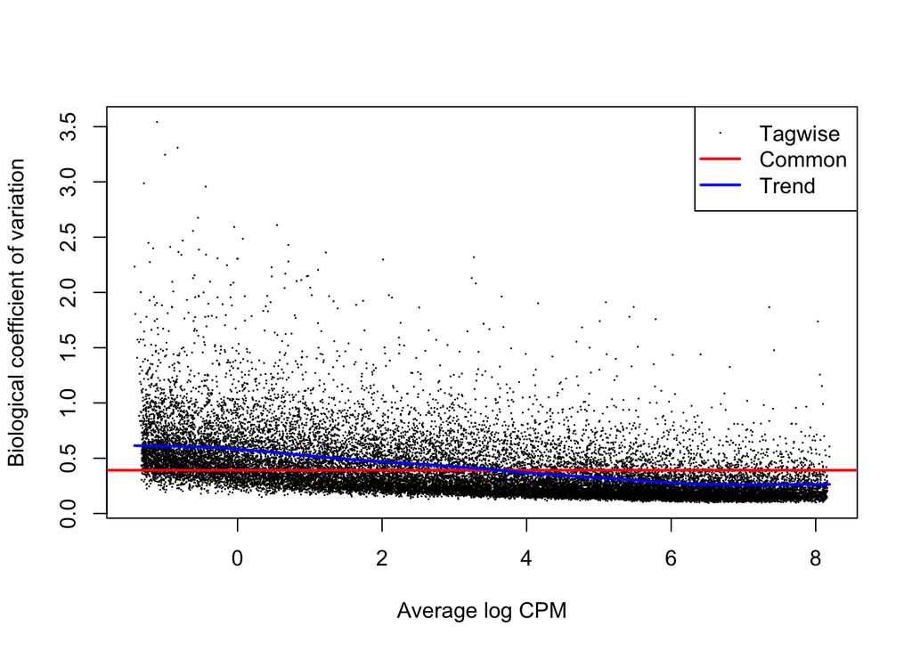

```r
y_for_DE_outliers <- DGEList(counts=counts_matrix_filtered)
y_for_DE_outliers <- calcNormFactors(y_for_DE_outliers)
y_for_DE_outliers = estimateDisp(y_for_DE_outliers, design=design_matrix_outliers)
plotBCV(y_for_DE_outliers)
```

```r
fit <- glmFit(y_for_DE_outliers, design=design_matrix_outliers, dispersion=y_for_DE_outliers$trended.dispersion)
```

Outlier vs everyone else

```r
lrt <- glmLRT(fit, coef = "OutlierStatusTRUE")
topTags(lrt)
```

```
## Coefficient:  OutlierStatusTRUE
##                    logFC   logCPM        LR        PValue           FDR
## ENSG00000145423 9.844115 3.518906 1144.5297 6.930616e-251 1.789208e-246
## ENSG00000186340 7.998066 3.946788 1039.0385 5.873128e-228 7.581034e-224
## ENSG00000011465 5.978499 5.538608  993.6405 4.331130e-218 3.727082e-214
## ENSG00000120708 4.947778 6.737254  878.1867 5.418064e-193 3.496819e-189
## ENSG00000182492 5.628015 5.339560  824.1768 2.990164e-181 1.543882e-177
## ENSG00000111341 7.040191 3.484323  729.1352 1.381147e-160 5.942617e-157
## ENSG00000087245 5.423678 4.889339  670.8997 6.367290e-148 2.348257e-144
## ENSG00000116132 8.332371 2.209045  658.7116 2.847985e-145 9.190448e-142
## ENSG00000130635 4.174457 7.870363  600.2087 1.508010e-132 4.325644e-129
## ENSG00000137573 5.250136 4.573998  578.6972 7.202047e-128 1.859281e-124
```

```r
counts_matrix_filtered_sansoutliers = counts_matrix_filtered[,!colnames(counts_matrix_filtered) %in% c("iHEP_20_NASH", "iHEP_22_NASH", "iHEP_54_CONTROL")]
DiseaseStatus_sansoutliers = factor(matrix (unlist(strsplit(colnames(counts_matrix_filtered_sansoutliers), "_")), byrow=T, ncol=3)[,3], levels = c("CONTROL","NASH"))
SampleID_sansoutliers = factor(matrix (unlist(strsplit(colnames(counts_matrix_filtered_sansoutliers), "_")), byrow=T, ncol=3)[,2])
cold_sansoutliers <- data.frame("DiseaseStatus_sansoutliers"=DiseaseStatus_sansoutliers)
rownames(cold_sansoutliers) = colnames(counts_matrix_filtered_sansoutliers)
cold_sansoutliers
```

```
##                  DiseaseStatus_sansoutliers
## iHEP_12_NASH                           NASH
## iHEP_131_NASH                          NASH
## iHEP_149_CONTROL                    CONTROL
## iHEP_15_NASH                           NASH
## iHEP_166_NASH                          NASH
## iHEP_172_NASH                          NASH
## iHEP_175_CONTROL                    CONTROL
## iHEP_182_NASH                          NASH
## iHEP_183_NASH                          NASH
## iHEP_184_NASH                          NASH
## iHEP_188_NASH                          NASH
## iHEP_190_CONTROL                    CONTROL
## iHEP_191_NASH                          NASH
## iHEP_192_CONTROL                    CONTROL
## iHEP_1_CONTROL                      CONTROL
## iHEP_201_NASH                          NASH
## iHEP_206_CONTROL                    CONTROL
## iHEP_21_CONTROL                     CONTROL
## iHEP_24_CONTROL                     CONTROL
## iHEP_27_CONTROL                     CONTROL
## iHEP_28_CONTROL                     CONTROL
## iHEP_2_CONTROL                      CONTROL
## iHEP_30_CONTROL                     CONTROL
## iHEP_37_CONTROL                     CONTROL
## iHEP_77_NASH                           NASH
## iHEP_7_NASH                            NASH
```

```r
ddsMat_sansoutliers <- DESeq2::DESeqDataSetFromMatrix(countData=counts_matrix_filtered_sansoutliers, colData=cold_sansoutliers, design=~DiseaseStatus_sansoutliers );
colnames(ddsMat_sansoutliers) <- colnames(counts_matrix_filtered_sansoutliers)
rld_sansoutliers <- DESeq2::rlog(ddsMat_sansoutliers) # LOG TRANSFORMED.
```

run PCA to explore structure in the data in lower dimensions.

```r
par(mfrow=c(2,1))
pca_sansoutliers <- prcomp(t(assay(rld_sansoutliers)))
```

Plot PC1 against PC2 using variance stabilizing transformation.

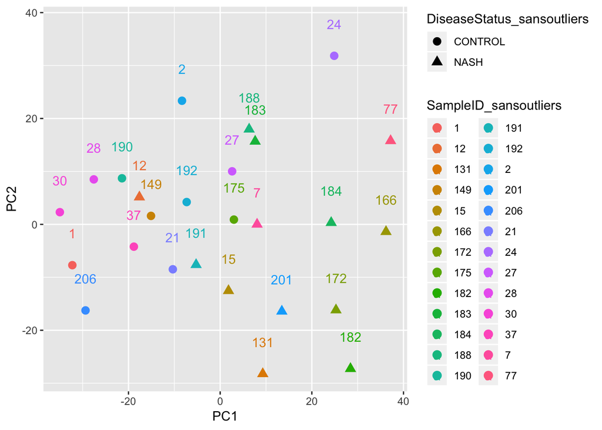

```r
d_sansoutliers <- data.frame(pca_sansoutliers$x, group=DiseaseStatus_sansoutliers, SampleID_sansoutliers,  name=colnames(rld_sansoutliers)) # returns PC1, PC2, ... PC8... etc
ppp_sansoutliers <- ggplot(d_sansoutliers, aes_string(x="PC1", y="PC2",shape="DiseaseStatus_sansoutliers", color="SampleID_sansoutliers"))
ppp_sansoutliers <- ppp_sansoutliers + geom_point(size=3) + geom_text(aes(label=SampleID_sansoutliers), nudge_y=6)
plot(ppp_sansoutliers)
```